# Data Import and Submission Export Tutorial

#### This tutorial will use python to import the data and output a sample submission.

To begin, make sure your python session has its working directory set to the same directory where your data is located. To view your current working directory, run the command `os.getcwd()` from the `os` module in the python console. You can use the `os.chdir('insert/your/path/to/data.csv')` command to set your working directory.

To double check that `trainingData.csv` and `testingData.csv` are in your current working directory, the following command should return TRUE twice, as seen in the output below.

```python
import os

list(x in os.listdir('.') for x in ['trainingData.csv', 'testingData.csv'])
```

```
[True, True]
```

## Data Import

Now that we have a python session with our two data files in the working directory, read the comma separated data using the `read_csv()` method from the `pandas` module and view a few predictor summaries.

```python
import pandas as pd

train = pd.read_csv('trainingData.csv')
```

```python
train.head()
```

|  | businessName | inspectionId | license | facilityType | risk | inspectionDate | inspectionType | pastFail | timeSinceLast | licenseStartDate | ... | addressCount | wardCount | districtCount | foodType | burglary | sanitation | garbage | rodents | pastResponse | response |
| --- | --- | --- | --- | --- | --- | --- | --- | --- | --- | --- | --- | --- | --- | --- | --- | --- | --- | --- | --- | --- | --- |
| 0 | MOBIL FOOD MART | 1229233 | 6381 | Other | Risk 1 (High) | 2012-05-30 | Canvass | 0 | 0.726027 | 2010-06-16 | ... | 1 | 1 | 1 | mart | 59.122170 | 9.737389 | 10.082827 | 32.685769 | 0 | 0 |
| 1 | M HENRIETTA | 1235275 | 2037187 | Restaurant | Risk 1 (High) | 2012-07-11 | Canvass | 0 | 1.449315 | 2012-06-16 | ... | 1 | 1 | 1 | unknown | 34.197993 | 22.271883 | 6.575097 | 35.635984 | 0 | 0 |
| 2 | BARBECUE KING RESTAURANT | 1228106 | 32172 | Restaurant | Risk 1 (High) | 2013-08-19 | Canvass | 0 | 1.043836 | 2012-06-16 | ... | 1 | 1 | 1 | dinner | 24.710126 | 9.452417 | 23.958758 | 19.817112 | 1 | 0 |
| 3 | KENTUCKY FRIED CHICKEN | 545792 | 2016979 | Restaurant | Risk 2 (Medium) | 2012-01-31 | Canvass | 0 | 1.989041 | 2011-06-16 | ... | 2 | 2 | 2 | dinner | 47.697951 | 10.977072 | 42.402077 | 8.539385 | 0 | 0 |
| 4 | HARRY CARAY'S SEVENTH INNING STRETCH | 1227635 | 1165412 | Restaurant | Risk 1 (High) | 2012-10-25 | Canvass | 0 | 0.619178 | 2012-01-16 | ... | 1 | 1 | 1 | unknown | 1.802808 | 1.872042 | 0.361587 | 1.118123 | 0 | 0 |

5 rows × 41 columns

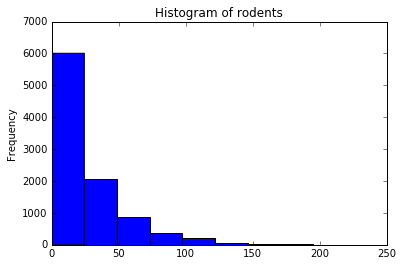

```python
%matplotlib inline
import matplotlib.pyplot as plt

train.rodents.plot.hist()
plt.title('Histogram of rodents')
```

```python
train.burglary.describe()
```

```
count     9.652000e+03
mean      2.093859e+01
std       1.674132e+01
min      1.291517e-218
25%       9.151607e+00
50%       1.757430e+01
75%       2.866602e+01
max       1.451209e+02
Name: burglary, dtype: float64
```

Also read the test set into your python session via the `pd.read_csv()` method

```python
test = pd.read_csv('testingData.csv')
```

```python
test.head()
```

|  | businessName | inspectionId | license | facilityType | risk | inspectionDate | inspectionType | pastFail | timeSinceLast | licenseStartDate | ... | fillingStation | addressCount | wardCount | districtCount | foodType | burglary | sanitation | garbage | rodents | pastResponse |
| --- | --- | --- | --- | --- | --- | --- | --- | --- | --- | --- | --- | --- | --- | --- | --- | --- | --- | --- | --- | --- | --- |
| 0 | 1155 CAFE | 1319523 | 33354 | Restaurant | Risk 1 (High) | 2013-05-06 | Canvass | 0 | 1.093151 | 2011-07-16 | ... | 0 | 1 | 1 | 1 | breakfast | 4.539479 | 2.194615 | 0.085212 | 0.286941 | 0 |
| 1 | 13 PINS TAPAS & GRILL | 1271208 | 2048477 | Restaurant | Risk 1 (High) | 2012-06-04 | Canvass | 1 | 0.032877 | 2010-09-24 | ... | 0 | 1 | 1 | 1 | dinner | 32.908279 | 25.629973 | 3.250397 | 13.901686 | 0 |
| 2 | 1.61 AND THE BAR10DOORS | 659700 | 2013819 | Restaurant | Risk 1 (High) | 2011-12-14 | Canvass | 0 | 1.632877 | 2010-05-05 | ... | 0 | 1 | 1 | 1 | unknown | 19.476143 | 10.043457 | 10.763469 | 1.926003 | 1 |
| 3 | 175 SOPRAFFINA MARKET CAFFE LLC | 614596 | 1422648 | Restaurant | Risk 1 (High) | 2011-11-09 | Canvass | 0 | 0.726027 | 2010-04-16 | ... | 0 | 1 | 1 | 1 | grocery | 8.399749 | 15.916425 | 0.000023 | 11.377409 | 0 |
| 4 | #1 CHOP SUEY | 1271460 | 1970042 | Restaurant | Risk 1 (High) | 2012-11-30 | Canvass | 0 | 0.602740 | 2011-08-16 | ... | 0 | 2 | 2 | 2 | asian | 9.711408 | 9.794065 | 11.262036 | 12.469862 | 0 |

5 rows × 40 columns

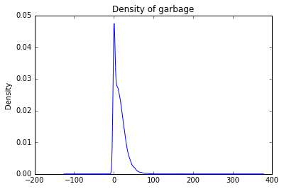

```python
train.garbage.plot.density()
plt.title('Density of garbage')
```

```python
train.shape
```

```
(9652, 41)
```

```python
test.shape
```

```
(2414, 40)
```

The training and testing sets have a different number of columns. This is, of course, because the test set does not contain the response variable. The following command will tell us which column is contained in the training set and not in the testing set.

```python
is_column_missing = list(column not in test.columns for column in train.columns)
train.columns[is_column_missing]
```

```
Index([u'response'], dtype='object')
```

## Data Export

When making a submission, the predictions need to be exported in a certain fashion. The example below will generate random uniform numbers and use them as our predictions.

```python
import numpy as np

numberOfObservationsInTestSet = len(test.index)
arrayOfPredictions = np.random.rand(numberOfObservationsInTestSet)
```

```python
np.percentile(arrayOfPredictions, [0, 25, 50, 75, 100])
```

```
array([  3.09669242e-05,   2.56712926e-01,   5.12312064e-01,
         7.53460425e-01,   9.99453743e-01])
```

```python
outputDataSet = pd.DataFrame({'inspectionId': test.inspectionId,
                              'response': arrayOfPredictions
                             })
```

Inspect dataset before export

```python
outputDataSet.head()
```

|  | inspectionId | response |
| --- | --- | --- |
| 0 | 1319523 | 0.303434 |
| 1 | 1271208 | 0.685869 |
| 2 | 659700 | 0.521719 |
| 3 | 614596 | 0.323142 |
| 4 | 1271460 | 0.079881 |

The following command will output a comma separated file to the current working directory. Find your current working directory again by executing the `os.getcwd()` command.

```python
outputDataSet.to_csv('submissionExample.csv', index = False)
```